# EDA HS22 - Mini-Challenge: Hotelbuchungen

**Beginn: 15.11.2022, 08:15**

**Ende: 25.11.2022, 23:59**

**Abgabe: Pro Zweiergruppe ein .Rmd und .html File via e-mail an daniel.perruchoud@fhnw.ch**

**Vorname, Name:**

**Vorname, Name:**

**Erreichte Punktzahl:**

**Note:**

**Hiermit erklären wir, dass die vorliegende Arbeit selbständig und ohne Hilfe weiterer Personen erarbeitet und geschrieben wurde und auch nicht an andere Personen weitergereicht wurde und wird.**

# Einführung

## Beurteilungskriterien

Beurteilt werden Umfang, Inhalt und Form der Abgabe jeder Gruppe; die pro Aufgabe erworbenen Punktezahl bestimmt sich aus Vollständigkeit, Korrektheit der Analyse sowie Qualität der Codierung.

Die **maximale** Anzahl möglicher Punkte ist hinter jeder Aufgabe vermerkt.

Sprache: Empfohlen ist in den Codes, Grafiken und Tabellen konsistent Englisch zu verwenden, damit die Namen der Attribute nicht übersetzt werden müssen.

Visualisierung: Bitte achtet darauf, dass alle Grafiken übersichtlich und vollständig beschriftet und koloriert sind und die Art der verwendeten Grafik entsprechend dem Datentyp sinnvoll gewählt ist.

Dokumentation: Kommentiert eure Codes, wo spezielle Überlegung einfliessen und beschreibt die Resulate der Analysen in wenigen Sätzen präzise.

## Datenbeschreibung

Ihr erhaltet Daten von 40’060 Hotelbuchungen und den Auftrag diese zu analysieren. Pro Buchung stehen die folgenden 31 Attribute zur Verfügung (zusammengehörende Attribute werden gemeinsam beschrieben).

1. IsCanceled: Information, ob die Buchung storniert wurde,
2. LeadTime: Anzahl Tage zwischen Buchung und Eintreffen im Hotel,
3. ArrivalDateYear, -Month, -DateWeekNumber, DateDayOfMonth: Information zum Zeitpunkt des Eintreffens im Hotel,
4. StaysInWeekendNights, StaysInWeekNights: Anzahl gebuchter Nächte am Wochenende, bzw. an Werktagen,
5. Adults, Children, Babies: Anzahl Erwachsene, Kinder und Babies pro Buchung,
6. Meal: Art des gebuchten Verpflegungen, d.h. BB (Bed & Breakfast), HB (Half board oder Halbpension), FB (Full board oder Vollpension), Undefined (kein Paket),
7. Country: Herkunftsland des Gastes,
8. MarketSegment: Marktsegment der Buchung, wie z.B. Geschäftskunde, Direktkunde, Gruppe (TA = Tour Agents, TO = Tour Operators),
9. DistributionChannel: Vertriebskanal der Buchung (TA = Tour Agents, TO = Tour Operators),
10. IsRepeatedGuest: Information, ob die Buchung einem früheren Gast zugewiesen werden kann,
11. PreviousCancellations: Information zur Anzahl früherer Stornierungen des Gastes,
12. PreviousBookingsNotCanceled: Information zur Anzahl früherer Buchung des Gastes ohne Stornierung,
13. ReservedRoomType / AssignedRoomType: reservierter Zimmertyp, bzw. tatsächlich bezogener Zimmertyp,
14. BookingChanges: Anzahl Anpassungen der Buchung bis zum Check-In bzw. bis zur Stornierung,
15. DepositType: Art der bei Buchung hinterlegten Sicherheit. Non-Refundable bedeutet der Gesamtbetrag wurde bezahlt und kann nicht zurückgefordert werden, Refundable bedeutet ein Teilbetrag wurde bezahlt und kann zurückgefordert werden,
16. Agent / Company: Agentur bzw. Firma, welche die Buchung durchgeführt hat,
17. DaysInWaitingList: Anzahl Tage bis der Gast die Bestätigung für die Buchung erhalten hat,
18. CustomerType: Kundenart des Gastes,
19. ADR: Average Daily Rate in EURO, d.h. durchschnittlich bezahlter Preis pro Übernachtung
20. RequiredCarParkingSpaces: Anzahl für den Gast benötigter Parkplätze,
21. TotalOfSpecialRequests: Anzahl spezieller Anfragen des Gastes (z.B. Kinderbett, Doppelbett),
22. ReservationStatus: letzter Status der Buchung (Check-Out, No-Show, Canceled),
23. ReservationStatusDate: letzter Statusänderung der Buchung.

# Analysen vorbereiten

## Aufgabe (1 Punkt): Lade die Analyse-Pakete

Lade die für die Analysen relevanten Pakete.

Hinweis: Verwende für deine Implementierung `tidyverse`, für Zeitreihenanalyse `lubridate` und zusätzlich `ggmosaic` und `knitr`.

```r
library(tidyverse)
library(lubridate)
library(ggmosaic)
library(knitr)
library(dplyr)
library(ggplot2)
```

# Daten laden und inspizieren

## Aufgabe (1 Punkt): Lade die Daten

Lade die zu analysierenden Daten.

Hinweis: Verwende für deine Implementierung die Funktion `read.csv()` und das File “H1.csv”.

```r
pathDenis <- "C:/Users/denis/OneDrive/Dokumente/FHNW/1.Sem/eda/Hotelchallenge/Daten/HS22_EDA_MC/H1.csv"
pathFlavio <- "/Users/flavio/Library/CloudStorage/OneDrive-FHNW/EDA/HS22_EDA_MC/H1.csv"
dataFrame <- read.csv(pathDenis)

dataFrame
```

| IsCanceled | LeadTime | ArrivalDateYear | ArrivalDateMonth | ArrivalDateWeekNumber | ArrivalDateDayOfMonth | StaysInWeekendNights | StaysInWeekNights | Adults | Children | Babies | Meal | Country | MarketSegment | DistributionChannel | IsRepeatedGuest | PreviousCancellations | PreviousBookingsNotCanceled | ReservedRoomType | AssignedRoomType | BookingChanges | DepositType | Agent | Company | DaysInWaitingList | CustomerType | ADR | RequiredCarParkingSpaces | TotalOfSpecialRequests | ReservationStatus | … |
| --- | --- | --- | --- | --- | --- | --- | --- | --- | --- | --- | --- | --- | --- | --- | --- | --- | --- | --- | --- | --- | --- | --- | --- | --- | --- | --- | --- | --- | --- | --- |
| 0 | 342 | 2015 | July | 27 | 1 | 0 | 0 | 2 | 0 | 0 | BB | PRT | Direct | Direct | 0 | 0 | 0 | C | C | 3 | No Deposit | NULL | NULL | 0 | Transient | 0.00 | 0 | 0 | Check-Out | … |
| 0 | 737 | 2015 | July | 27 | 1 | 0 | 0 | 2 | 0 | 0 | BB | PRT | Direct | Direct | 0 | 0 | 0 | C | C | 4 | No Deposit | NULL | NULL | 0 | Transient | 0.00 | 0 | 0 | Check-Out | … |
| 0 | 7 | 2015 | July | 27 | 1 | 0 | 1 | 1 | 0 | 0 | BB | GBR | Direct | Direct | 0 | 0 | 0 | A | C | 0 | No Deposit | NULL | NULL | 0 | Transient | 75.00 | 0 | 0 | Check-Out | … |
| 0 | 13 | 2015 | July | 27 | 1 | 0 | 1 | 1 | 0 | 0 | BB | GBR | Corporate | Corporate | 0 | 0 | 0 | A | A | 0 | No Deposit | 304 | NULL | 0 | Transient | 75.00 | 0 | 0 | Check-Out | … |
| 0 | 14 | 2015 | July | 27 | 1 | 0 | 2 | 2 | 0 | 0 | BB | GBR | Online TA | TA/TO | 0 | 0 | 0 | A | A | 0 | No Deposit | 240 | NULL | 0 | Transient | 98.00 | 0 | 1 | Check-Out | … |
| 0 | 14 | 2015 | July | 27 | 1 | 0 | 2 | 2 | 0 | 0 | BB | GBR | Online TA | TA/TO | 0 | 0 | 0 | A | A | 0 | No Deposit | 240 | NULL | 0 | Transient | 98.00 | 0 | 1 | Check-Out | … |
| 0 | 0 | 2015 | July | 27 | 1 | 0 | 2 | 2 | 0 | 0 | BB | PRT | Direct | Direct | 0 | 0 | 0 | C | C | 0 | No Deposit | NULL | NULL | 0 | Transient | 107.00 | 0 | 0 | Check-Out | … |
| 0 | 9 | 2015 | July | 27 | 1 | 0 | 2 | 2 | 0 | 0 | FB | PRT | Direct | Direct | 0 | 0 | 0 | C | C | 0 | No Deposit | 303 | NULL | 0 | Transient | 103.00 | 0 | 1 | Check-Out | … |
| 1 | 85 | 2015 | July | 27 | 1 | 0 | 3 | 2 | 0 | 0 | BB | PRT | Online TA | TA/TO | 0 | 0 | 0 | A | A | 0 | No Deposit | 240 | NULL | 0 | Transient | 82.00 | 0 | 1 | Canceled | … |
| 1 | 75 | 2015 | July | 27 | 1 | 0 | 3 | 2 | 0 | 0 | HB | PRT | Offline TA/TO | TA/TO | 0 | 0 | 0 | D | D | 0 | No Deposit | 15 | NULL | 0 | Transient | 105.50 | 0 | 0 | Canceled | … |

[output cut: 990 more lines]

## Aufgabe (1 Punkt): Untersuche die Grösse des Data Frames

Gib für die eingelesenen Daten die Anzahl Beobachtungen und Attribute aus.

```r
count(dataFrame) #Anzahl
```

| n |
| --- |
| 40060 |

```r
attributes(dataFrame) #Attribute
```

```
$names
 [1] "IsCanceled"                  "LeadTime"                    "ArrivalDateYear"             "ArrivalDateMonth"            "ArrivalDateWeekNumber"
 [6] "ArrivalDateDayOfMonth"       "StaysInWeekendNights"        "StaysInWeekNights"           "Adults"                      "Children"
[11] "Babies"                      "Meal"                        "Country"                     "MarketSegment"               "DistributionChannel"
[16] "IsRepeatedGuest"             "PreviousCancellations"       "PreviousBookingsNotCanceled" "ReservedRoomType"            "AssignedRoomType"
[21] "BookingChanges"              "DepositType"                 "Agent"                       "Company"                     "DaysInWaitingList"
[26] "CustomerType"                "ADR"                         "RequiredCarParkingSpaces"    "TotalOfSpecialRequests"      "ReservationStatus"
[31] "ReservationStatusDate"

$class
[1] "data.frame"

$row.names
   [1]    1    2    3    4    5    6    7    8    9   10   11   12   13   14   15   16   17   18   19   20   21   22   23   24   25   26   27   28   29   30   31   32
  [33]   33   34   35   36   37   38   39   40   41   42   43   44   45   46   47   48   49   50   51   52   53   54   55   56   57   58   59   60   61   62   63   64
```

[output cut: 31 more lines]

## Aufgabe (1 Punkt): Inspiziere die Dateninhalte

Gib eine Zufallsstichprobe von 5 Beobachtungen aus (verwende als Seed die Zahl 4711) und verschafffe dir einen Überblick über die Daten.

```r
set.seed(4711)
sampleRows <- sample(1:nrow(dataFrame), 5)
slice(dataFrame, sampleRows)
```

| IsCanceled | LeadTime | ArrivalDateYear | ArrivalDateMonth | ArrivalDateWeekNumber | ArrivalDateDayOfMonth | StaysInWeekendNights | StaysInWeekNights | Adults | Children | Babies | Meal | Country | MarketSegment | DistributionChannel | IsRepeatedGuest | PreviousCancellations | PreviousBookingsNotCanceled | ReservedRoomType | AssignedRoomType | BookingChanges | DepositType | Agent | Company | DaysInWaitingList | CustomerType | ADR | RequiredCarParkingSpaces | TotalOfSpecialRequests | ReservationStatus | … |
| --- | --- | --- | --- | --- | --- | --- | --- | --- | --- | --- | --- | --- | --- | --- | --- | --- | --- | --- | --- | --- | --- | --- | --- | --- | --- | --- | --- | --- | --- | --- |
| 0 | 388 | 2017 | May | 21 | 25 | 0 | 3 | 2 | 0 | 0 | BB | CN | Groups | TA/TO | 0 | 0 | 0 | E | E | 0 | No Deposit | 96 | NULL | 0 | Transient-Party | 72.00 | 0 | 1 | Check-Out | … |
| 1 | 328 | 2017 | June | 23 | 7 | 2 | 9 | 2 | 0 | 0 | BB | IRL | Online TA | TA/TO | 0 | 0 | 0 | A | A | 2 | No Deposit | 240 | NULL | 0 | Transient | 74.25 | 0 | 1 | Canceled | … |
| 1 | 96 | 2017 | March | 12 | 19 | 2 | 5 | 2 | 0 | 0 | BB | PRT | Groups | TA/TO | 0 | 0 | 0 | A | C | 1 | No Deposit | 177 | NULL | 0 | Transient-Party | 34.00 | 0 | 0 | Canceled | … |
| 1 | 32 | 2016 | April | 17 | 19 | 2 | 5 | 2 | 0 | 0 | HB | PRT | Groups | Direct | 0 | 0 | 0 | D | D | 0 | No Deposit | 273 | NULL | 0 | Transient-Party | 69.36 | 0 | 0 | Canceled | … |
| 0 | 152 | 2015 | July | 27 | 2 | 2 | 5 | 1 | 0 | 0 | HB | GBR | Offline TA/TO | TA/TO | 0 | 0 | 0 | A | A | 0 | No Deposit | 243 | NULL | 0 | Contract | 60.35 | 0 | 2 | Check-Out | … |

## Aufgabe (1 Punkt): Untersuche Struktur und Datentypen

Gib die Struktur des Data Frames aus und verschaffe dir einen Überblick über die Datentypen.

```r
glimpse(dataFrame)
```

```
Rows: 40,060
Columns: 31
$ IsCanceled                  <int> 0, 0, 0, 0, 0, 0, 0, 0, 1, 1, 1, 0, 0, 0, 0, 0, 0, 0, 0, 0, 0, 0, 0, 0, 0, 0, 0, 1, 0, 0, 0, 0, 1, 0, 1, 1, 0, 0, 1, 0, 1, 0, 0, 0, …
$ LeadTime                    <int> 342, 737, 7, 13, 14, 14, 0, 9, 85, 75, 23, 35, 68, 18, 37, 68, 37, 12, 0, 7, 37, 72, 72, 72, 127, 78, 48, 60, 77, 99, 118, 95, 96, 6…
$ ArrivalDateYear             <int> 2015, 2015, 2015, 2015, 2015, 2015, 2015, 2015, 2015, 2015, 2015, 2015, 2015, 2015, 2015, 2015, 2015, 2015, 2015, 2015, 2015, 2015, …
$ ArrivalDateMonth            <chr> "July", "July", "July", "July", "July", "July", "July", "July", "July", "July", "July", "July", "July", "July", "July", "July", "Jul…
$ ArrivalDateWeekNumber       <int> 27, 27, 27, 27, 27, 27, 27, 27, 27, 27, 27, 27, 27, 27, 27, 27, 27, 27, 27, 27, 27, 27, 27, 27, 27, 27, 27, 27, 27, 27, 27, 27, 27, …
$ ArrivalDateDayOfMonth       <int> 1, 1, 1, 1, 1, 1, 1, 1, 1, 1, 1, 1, 1, 1, 1, 1, 1, 1, 1, 1, 1, 1, 1, 1, 1, 1, 1, 1, 1, 1, 1, 1, 1, 2, 2, 2, 2, 2, 2, 2, 2, 2, 2, 2, …
$ StaysInWeekendNights        <int> 0, 0, 0, 0, 0, 0, 0, 0, 0, 0, 0, 0, 0, 0, 0, 0, 0, 0, 0, 0, 1, 2, 2, 2, 2, 2, 2, 2, 2, 2, 4, 4, 2, 2, 1, 1, 1, 1, 1, 2, 2, 2, 2, 2, …
$ StaysInWeekNights           <int> 0, 0, 1, 1, 2, 2, 2, 2, 3, 3, 4, 4, 4, 4, 4, 4, 4, 1, 1, 4, 4, 4, 4, 4, 5, 5, 5, 5, 5, 5, 10, 11, 8, 4, 3, 3, 3, 3, 3, 3, 3, 3, 3, 3…
$ Adults                      <int> 2, 2, 1, 1, 2, 2, 2, 2, 2, 2, 2, 2, 2, 2, 2, 2, 2, 2, 2, 2, 1, 2, 2, 2, 2, 2, 2, 2, 2, 2, 1, 2, 2, 2, 3, 3, 2, 3, 3, 2, 2, 2, 2, 2, …
$ Children                    <int> 0, 0, 0, 0, 0, 0, 0, 0, 0, 0, 0, 0, 0, 1, 0, 0, 0, 0, 0, 0, 0, 0, 0, 0, 0, 0, 0, 0, 0, 0, 0, 0, 0, 0, 0, 0, 0, 0, 0, 0, 0, 0, 0, 0, …
$ Babies                      <int> 0, 0, 0, 0, 0, 0, 0, 0, 0, 0, 0, 0, 0, 0, 0, 0, 0, 0, 0, 0, 0, 0, 0, 0, 0, 0, 0, 0, 0, 0, 0, 0, 0, 0, 0, 0, 0, 0, 0, 0, 0, 0, 0, 0, …
$ Meal                        <chr> "BB       ", "BB       ", "BB       ", "BB       ", "BB       ", "BB       ", "BB       ", "FB       ", "BB       ", "HB       ", "B…
$ Country                     <chr> "PRT", "PRT", "GBR", "GBR", "GBR", "GBR", "PRT", "PRT", "PRT", "PRT", "PRT", "PRT", "USA", "ESP", "PRT", "IRL", "PRT", "IRL", "FRA",…
```

[output cut: 18 more lines]

## Aufgabe (2 Punkte): Identifiziere Duplikate

Bestimme wieviele doppelte Beobachtungen im Data Frame auftauchen.

Hinweis: Aufgrund fehlender Hintergrundinformationen werden für die nächsten Schritte zunächst keine Beobachtungen entfernt, auch wenn im Datensatz viel redundante Informationen vorhanden sind!

```r
duplicateList <- dataFrame[duplicated(dataFrame), ]
newList <- duplicateList %>% group_by_all() %>% summarise(n = n())
print(sum(newList$n))
```

```
[1] 6092
```

## Aufgabe (10 Punkte): Identifiziere Gruppen doppelter Beobachtungen

Doppelte Beobachtungen treten im vorliegenden Datensatz in unterschiedlicher Gruppierung auf: es gibt Beobachtungen, die nur zweimal, aber auch Beobachtungen, die mehr als ein Dutzend mal vorhanden sind. Gib für die vier Gruppierungen mit den meisten doppelten Beobachtungen je eine vollständige Beobachtung aus.

Hinweis: Aufgrund fehlender Hintergrundinformationen werden für die nächsten Schritte zunächst keine Beobachtungen entfernt, auch wenn im Datensatz viel redundante Informationen vorhanden sind!

```r
biggestDuplicates <- newList[order(newList$n, decreasing = TRUE),]

biggestDuplicates <- biggestDuplicates[1:4,]
```

[output not shown]

# Daten transformieren

## Aufgabe (2 Punkte): Benenne Attribute um

Die folgenden Attribute sind neu zu benennen (alterName -> neuerName)

- TotalOfSpecialRequests -> TotalSpecialRequests
- ADR -> AverageDailyRate
- IsCanceled -> BookingCancelled

```r
#names(dataFrame)

dataFrame <- dataFrame %>% rename(
  BookingCancelled = IsCanceled,
  AverageDailyRate = ADR,
  TotalSpecialRequests = TotalOfSpecialRequests
  )
```

## Aufgabe (2 Punkte): Entferne Leerzeichen

Entferne *gleichzeitig für alle* character-wertigen Attribute, die Leerzeichen, welche vor oder nach dem Text auftauchen.

Hinweis: Verwende für deine Implementierung die Funktion `across()` und den Post [Umgang mit textuellen Daten mit tidyverse’s stringr](https://spaces.technik.fhnw.ch/spaces/explorative-datenanalyse/beitraege/umgang-mit-textuellen-daten-mit-tidyverses-stringr).

```r
library(stringr)
dataFrame <- dataFrame %>%
  mutate(across(where(is.character), str_trim))

#glimpse(dataFrame)
```

## Aufgabe (2 Punkte): Untersuche fehlende Informationen

Untersuche allfällige fehlende Informationen (NAs) im Data Frame und zähle wieviele NAs vorkommen.

```r
#Aufpassen bei bestimmten Funktionen werden fehlende Informationen automatisch als N/A kategorisiert
#Keine NAs vorhanden, gibt es fehlende Informationen?
sapply(dataFrame, function(x) sum(is.na(x)))
```

```
           BookingCancelled                    LeadTime             ArrivalDateYear            ArrivalDateMonth       ArrivalDateWeekNumber       ArrivalDateDayOfMonth
                          0                           0                           0                           0                           0                           0
       StaysInWeekendNights           StaysInWeekNights                      Adults                    Children                      Babies                        Meal
                          0                           0                           0                           0                           0                           0
                    Country               MarketSegment         DistributionChannel             IsRepeatedGuest       PreviousCancellations PreviousBookingsNotCanceled
                          0                           0                           0                           0                           0                           0
           ReservedRoomType            AssignedRoomType              BookingChanges                 DepositType                       Agent                     Company
                          0                           0                           0                           0                           0                           0
          DaysInWaitingList                CustomerType            AverageDailyRate    RequiredCarParkingSpaces        TotalSpecialRequests           ReservationStatus
                          0                           0                           0                           0                           0                           0
      ReservationStatusDate
                          0
```

## Aufgabe (3 Punkte): Ersetze “NULL” Werte

Ersetze *gleichzeitig alle* Werte “NULL” für die Attribute “Company” und “Agent” durch `NA` und und zähle wieviele NAs in jedem der beiden Attributen vorkommen.

```r
#!!!Funktioniert aber ändert nur die Namen nicht den tatsächlichen Wert, muss noch überarbeitet werden, denke ich!!
NAs <- c("Company", "Agent")
dataFrame <- dataFrame %>%
  mutate_at(vars(NAs), ~ str_replace(., "NULL", "NA"))
```

[output not shown]

## Aufgabe (4 Punkte): Ersetze Abkürzungen

Ersetze *gleichzeitig* für die Attribute “MarketSegment” und “DistributionChannel” die Abkürzungen

- “TA” durch “Tour Agent”,
- “TO” durch “Tour Operator”.

Hinweis: Verwende für deine Implementierung die Funktion `gsub()` oder Ähnliches.

```r
 dataFrame <- dataFrame %>%
       mutate(across(c(MarketSegment, DistributionChannel), ~ gsub("TA", "Tour Agent", gsub("TO", "Tour Operator", .))))
```

## Aufgabe (4 Punkte): Ersetze weitere Abkürzungen

Ersetze für das Attribut “Meal” die verwendeten Abkürzungen

- “BB” durch “Bed & Breakfast”,
- “HB” durch “Half board”,
- “FB” durch “Full board”,
- “Undefined” durch “kein Paket”.

Ersetze weiter für die Attribute “BookingCancelled” und “IsRepeatedGuest” die Werte 1 durch “Yes” und 0 durch “No”.

```r
dataFrameOld <- dataFrame
dataFrame$Meal <- gsub("BB", "Bed & Breakfast",
                  gsub("HB", "Half board",
                  gsub("FB", "Full board",
                  gsub("Undefined", "kein Paket", dataFrame$Meal))))

dataFrame <- dataFrame %>% mutate(BookingCancelled=recode(BookingCancelled, "1"="Yes", "0"="No"))
dataFrame <- dataFrame %>% mutate(IsRepeatedGuest=recode(IsRepeatedGuest, "1"="Yes", "0"="No"))
```

## Aufgabe (6 Punkte): Erstelle Datumsvariablen

Erstelle Datumsvariablen für Reservation und Ankunft aufgrund der Informationen “ReservationStatusDate” bzw. “ArrivalDateYear”, “ArrivalDateYear”, “ArrivalDateDayOfMonth”.

Hinweis: Verwende für deine Implementierung die library `lubridate` und Informationen aus [R for Data Science, Chapter “Dates and times”](https://r4ds.had.co.nz/dates-and-times.html) sowie die Posts [Umgang mit Datumsinformationen](https://spaces.technik.fhnw.ch/spaces/explorative-datenanalyse/beitraege/umgang-mit-datumsinformationen) und [Umgang mit textuellen Daten mit tidyverse’s stringr](https://spaces.technik.fhnw.ch/spaces/explorative-datenanalyse/beitraege/umgang-mit-textuellen-daten-mit-tidyverses-stringr).

```r
dataFrame <- cbind(dataFrame, ArrivalDate = mdy(str_c(str_c(dataFrame$ArrivalDateMonth, dataFrame$ArrivalDateDayOfMonth, sep = " "), dataFrame$ArrivalDateYear, sep = ", ")))

dataFrame <- dataFrame[order(dataFrame$ArrivalDate), ]
dataFrame$ReservationStatusDate <- as.Date(dataFrame$ReservationStatusDate)
```

## Aufgabe (3 Punkte): Bilde Faktoren

Konvertiere sämtliche kategorialen Variablen und mache daraus Faktoren und überprüfe die Datentypen der konvertierten Variablen für die Variablen “BookingCancelled” und “DepositType”.

Hinweis: Verwende für deine Implementierung `across()` und eine bestehende R Basis-Funktion zur Prüfung der erfolgreichen Bildung der Faktoren.

```r
#kategoriale Variablen: Meal,Country, Marketsegment, Distributionschannel, ReservedRoomType, AssignedRoomType, DepositType, Agent, Company, Customertype, Average Daily Rate.
#Diese gilt es als factor Variablen darzustellen, habe ich leider nich geschafft. Denis probieren.
#Gibts es noch mehr kategoriale Variablen?

dataFrame <- dataFrame %>%
  mutate(across(c(Meal, Country, DistributionChannel, ReservedRoomType, AssignedRoomType, DepositType, Agent, Company, CustomerType, BookingCancelled, IsRepeatedGuest, ReservationStatus, MarketSegment), ~ factor(.)))




#Überprüfen mit R Basis Funktion
sapply(dataFrame, class)
```

```
           BookingCancelled                    LeadTime             ArrivalDateYear            ArrivalDateMonth       ArrivalDateWeekNumber       ArrivalDateDayOfMonth
                   "factor"                   "integer"                   "integer"                 "character"                   "integer"                   "integer"
       StaysInWeekendNights           StaysInWeekNights                      Adults                    Children                      Babies                        Meal
                  "integer"                   "integer"                   "integer"                   "integer"                   "integer"                    "factor"
                    Country               MarketSegment         DistributionChannel             IsRepeatedGuest       PreviousCancellations PreviousBookingsNotCanceled
                   "factor"                    "factor"                    "factor"                    "factor"                   "integer"                   "integer"
           ReservedRoomType            AssignedRoomType              BookingChanges                 DepositType                       Agent                     Company
                   "factor"                    "factor"                   "integer"                    "factor"                    "factor"                    "factor"
          DaysInWaitingList                CustomerType            AverageDailyRate    RequiredCarParkingSpaces        TotalSpecialRequests           ReservationStatus
                  "integer"                    "factor"                   "numeric"                   "integer"                   "integer"                    "factor"
      ReservationStatusDate                 ArrivalDate
                     "Date"                      "Date"
```

## Aufgabe (7 Punkte): Erstelle neue Variablen

Erstelle neue Variablen, welche Auskunft geben über

- die Anzahl Logiernächte pro Buchung -> neue Variable “TotalNights” als Summe der Anzahl Nächte an Wochentagen (“StaysInWeekNights) und Wochenendtagen (”StaysInWeekendNights”),
- die Anzahl Personen pro Buchung -> neue Variable “GroupSize” als Summe von “Adults”, “Children” und “Babies”,
- den bezahlten Preis pro Aufenthalt -> neue Variable “Price” gebildet als Produkt von “AverageDailyRate” und “TotalNights”.

Erstelle daraus abgeleitet weitere Attribute für die Art des Aufenthalts (neue Faktor-Variable “StayType”):

- “Long stay” definiert als Aufenthalt von mehr als 7 Nächten,
- “Full week” definiert als Aufenthalt von 7 Nächten,
- “Week stay” definiert als Aufenthalt von weniger als 7 Tagen ohne Wochenendübernachtungen,
- “Weekend only” definiert als eintägiger Aufenthalt mit einer Wochenendübernachtung,
- “Long weekend” definiert als zweitägiger Aufenthalt mit zwei Wochenendübernachtungen,

sowie den Haushaltstyp (neue Faktor-Variable “HouseholdType”):

- “Single” definiert als Buchung für genau eine Erwachsene,
- “Couple” definiert als Buchung für genau zwei Erwachsene,
- “Single Parent” definiert als Buchung für eine Erwachsene und ein oder mehrere Kinder oder Babies,
- “Family” definiert als Buchung für zwei Erwachsene und ein oder mehrere Kinder oder Babies,
- “Group” definiert als Buchung für mehr als zwei Erwachsene (mit oder ohne Kinder / Babies),

```r
#TotalNights Variable erstellen
dataFrame$TotalNights <- dataFrame$StaysInWeekNights + dataFrame$StaysInWeekendNights
#GroupSize Variable erstellen
dataFrame$GroupSize <- dataFrame$Adults + dataFrame$Children + dataFrame$Babies
#Price Variable erstellen
dataFrame$Price <- dataFrame$AverageDailyRate * dataFrame$TotalNights

#StayType Variable erstellen
dataFrame <- dataFrame %>%
  mutate(StayType = case_when(TotalNights > 7 ~ "Long Stay",
                              TotalNights == 7 ~ "Full week",
                              StaysInWeekNights < 7 & StaysInWeekendNights == 0 ~ "Week Stay",
                              TotalNights == 1 & StaysInWeekendNights == 1 ~ "Weekend only",
                              StaysInWeekNights == 0 & StaysInWeekendNights == 2 ~ "Long Weekend"))
dataFrame$StayType <- as.factor(dataFrame$StayType)



#HouseholdType Variable erstellen     adults, children, babies
dataFrame <-dataFrame %>%
  mutate(HouseholdType = case_when(Adults == 1 & Children == 0 & Babies == 0 ~ "Single",
                                   Adults == 2 & Children == 0 & Babies == 0 ~ "Couple",
                                   Adults == 1 & Children >= 0 & Babies >= 0 ~ "Single Parent",
                                   Adults == 2 & Children >= 0 & Babies >= 0 ~ "Family",
                                   Adults >  2 & Children >= 0 & Babies >= 0 ~ "Group"))
dataFrame$HouseholdType <- as.factor(dataFrame$HouseholdType)
```

# Summarische Statistiken erzeugen

## Aufgabe (3 Punkte): Erstelle Häufigkeitstabellen

Gib für die beiden oben bearbeiteten Attribute “MarketSegment” und “DistributionChannel” je eine separate Häufigkeitstabelle aus.

Hinweis: Verwende für deine Implementierung nur **einen** Aufruf der Funktion `summary()`.

```r
summary(dataFrame[,c("MarketSegment", "DistributionChannel")])
```

```
                          MarketSegment                 DistributionChannel
 Complementary                   :  201   Corporate               : 3269
 Corporate                       : 2309   Direct                  : 7865
 Direct                          : 6513   Tour Agent/Tour Operator:28925
 Groups                          : 5836   Undefined               :    1
 Offline Tour Agent/Tour Operator: 7472
 Online Tour Agent               :17729
```

## Aufgabe (3 Punkte): Erstelle weitere Häufigkeitstabellen

Gib für die Attribute “Meal” und “IsRepeatedGuest” separat tabellarische Häufigkeitsverteilungen aus.

Hinweis: Verwende für deine Implementierung die Funktion `kable()`.

```r
cleanedList <- dataFrame
#Meals
freqTableMeal <- cleanedList %>% group_by(Meal = cleanedList$Meal) %>% summarise(Count = n())
freqTableMeal <- freqTableMeal[order(freqTableMeal$Count, decreasing = TRUE),]
totalSegments <- sum(freqTableMeal$Count)
freqTableMeal <- cbind(freqTableMeal, Percentage = freqTableMeal$Count/totalSegments * 100)
kable(freqTableMeal, digits = 2, format = "pipe")
```

| Meal | Count | Percentage |
| --- | --- | --- |
| Bed & Breakfast | 30005 | 74.90 |
| Half board | 8046 | 20.08 |
| kein Paket | 1169 | 2.92 |
| Full board | 754 | 1.88 |
| SC | 86 | 0.21 |

```r
#IsRepeatedGuest
freqTableIsRepeatedGuest <- cleanedList %>% group_by(IsRepeatedGuest = cleanedList$IsRepeatedGuest) %>% summarise(Count = n())
freqTableIsRepeatedGuest <- freqTableIsRepeatedGuest[order(freqTableIsRepeatedGuest$Count, decreasing = TRUE),]
totalSegments <- sum(freqTableIsRepeatedGuest$Count)
freqTableIsRepeatedGuest <- cbind(freqTableIsRepeatedGuest, Percentage = freqTableIsRepeatedGuest$Count/totalSegments * 100)
kable(freqTableIsRepeatedGuest, digits = 2, format = "pipe")
```

| IsRepeatedGuest | Count | Percentage |
| --- | --- | --- |
| No | 38282 | 95.56 |
| Yes | 1778 | 4.44 |

```r
NA
```

## Aufgabe (5 Punkte): Erstelle weitere Häufigkeitstabellen

Erstelle eine summarische, univariate Statistik für alle Attribute und dokumentiere kurz allfällige Besonderheiten.

```r
summary(dataFrame)
```

```
 BookingCancelled    LeadTime      ArrivalDateYear ArrivalDateMonth   ArrivalDateWeekNumber ArrivalDateDayOfMonth StaysInWeekendNights StaysInWeekNights     Adults
 No :28938        Min.   :  0.00   Min.   :2015    Length:40060       Min.   : 1.00         Min.   : 1.00         Min.   : 0.00        Min.   : 0.000    Min.   : 0.000
 Yes:11122        1st Qu.: 10.00   1st Qu.:2016    Class :character   1st Qu.:16.00         1st Qu.: 8.00         1st Qu.: 0.00        1st Qu.: 1.000    1st Qu.: 2.000
                  Median : 57.00   Median :2016    Mode  :character   Median :28.00         Median :16.00         Median : 1.00        Median : 3.000    Median : 2.000
                  Mean   : 92.68   Mean   :2016                       Mean   :27.14         Mean   :15.82         Mean   : 1.19        Mean   : 3.129    Mean   : 1.867
                  3rd Qu.:155.00   3rd Qu.:2017                       3rd Qu.:38.00         3rd Qu.:24.00         3rd Qu.: 2.00        3rd Qu.: 5.000    3rd Qu.: 2.000
                  Max.   :737.00   Max.   :2017                       Max.   :53.00         Max.   :31.00         Max.   :19.00        Max.   :50.000    Max.   :55.000

    Children           Babies                    Meal          Country                               MarketSegment                 DistributionChannel IsRepeatedGuest
 Min.   : 0.0000   Min.   :0.0000   Bed & Breakfast:30005   PRT    :17630   Complementary                   :  201   Corporate               : 3269    No :38282
 1st Qu.: 0.0000   1st Qu.:0.0000   Full board     :  754   GBR    : 6814   Corporate                       : 2309   Direct                  : 7865    Yes: 1778
 Median : 0.0000   Median :0.0000   Half board     : 8046   ESP    : 3957   Direct                          : 6513   Tour Agent/Tour Operator:28925
 Mean   : 0.1287   Mean   :0.0139   kein Paket     : 1169   IRL    : 2166   Groups                          : 5836   Undefined               :    1
 3rd Qu.: 0.0000   3rd Qu.:0.0000   SC             :   86   FRA    : 1611   Offline Tour Agent/Tour Operator: 7472
 Max.   :10.0000   Max.   :2.0000                           DEU    : 1203   Online Tour Agent               :17729
                                                            (Other): 6679
 PreviousCancellations PreviousBookingsNotCanceled ReservedRoomType AssignedRoomType BookingChanges       DepositType        Agent          Company
 Min.   : 0.0000       Min.   : 0.0000             A      :23399    A      :17046    Min.   : 0.000   No Deposit:38199   240    :13905   NA     :36952
 1st Qu.: 0.0000       1st Qu.: 0.0000             D      : 7433    D      :10339    1st Qu.: 0.000   Non Refund: 1719   NA     : 8209   223    :  784
 Median : 0.0000       Median : 0.0000             E      : 4982    E      : 5638    Median : 0.000   Refundable:  142   250    : 2869   281    :  138
 Mean   : 0.1017       Mean   : 0.1465             G      : 1610    C      : 2214    Mean   : 0.288                      241    : 1721   154    :  133
 3rd Qu.: 0.0000       3rd Qu.: 0.0000             F      : 1106    G      : 1853    3rd Qu.: 0.000                      40     : 1002   405    :  100
 Max.   :26.0000       Max.   :30.0000             C      :  918    F      : 1733    Max.   :17.000                      314    :  927   94     :   87
                                                   (Other):  612    (Other): 1237                                        (Other):11427   (Other): 1866
 DaysInWaitingList           CustomerType   AverageDailyRate RequiredCarParkingSpaces TotalSpecialRequests ReservationStatus ReservationStatusDate  ArrivalDate
 Min.   :  0.0000   Contract       : 1776   Min.   : -6.38   Min.   :0.0000           Min.   :0.0000       Canceled :10831   Min.   :2014-11-18    Min.   :2015-07-01
 1st Qu.:  0.0000   Group          :  284   1st Qu.: 50.00   1st Qu.:0.0000           1st Qu.:0.0000       Check-Out:28938   1st Qu.:2016-01-26    1st Qu.:2016-02-14
 Median :  0.0000   Transient      :30209   Median : 75.00   Median :0.0000           Median :0.0000       No-Show  :  291   Median :2016-07-31    Median :2016-08-19
 Mean   :  0.5278   Transient-Party: 7791   Mean   : 94.95   Mean   :0.1381           Mean   :0.6198                         Mean   :2016-07-28    Mean   :2016-08-15
 3rd Qu.:  0.0000                           3rd Qu.:125.00   3rd Qu.:0.0000           3rd Qu.:1.0000                         3rd Qu.:2017-02-11    3rd Qu.:2017-03-05
 Max.   :185.0000                           Max.   :508.00   Max.   :8.0000           Max.   :5.0000                         Max.   :2017-09-14    Max.   :2017-08-31

  TotalNights       GroupSize         Price                StayType           HouseholdType
 Min.   : 0.000   Min.   : 0.00   Min.   : -63.8   Full week   : 6596   Couple       :28034
 1st Qu.: 2.000   1st Qu.: 2.00   1st Qu.: 117.0   Long Stay   : 4009   Family       : 3391
 Median : 3.000   Median : 2.00   Median : 273.0   Long Weekend:  559   Group        : 1474
 Mean   : 4.319   Mean   : 2.01   Mean   : 435.4   Week Stay   :14181   Single       : 7013
 3rd Qu.: 7.000   3rd Qu.: 2.00   3rd Qu.: 593.0   Weekend only: 1739   Single Parent:  135
 Max.   :69.000   Max.   :55.00   Max.   :7590.0   NA's        :12976   NA's         :   13
```

## Aufgabe (4 Punkte): Prüfe Auffälligkeiten

Erstelle eine tabellarische Häufigkeitsverteilung für das neu gebildete Attribut “HouseholdType” und untersuche und beschreibe Auffälligkeiten.

Hinweis: Verwende für deine Implementierung die Funktion `kable()`.

```r
#HouseholdType
freqTableHouseholdType <- cleanedList %>% group_by(HouseholdType = cleanedList$HouseholdType) %>% summarise(Count = n())
freqTableHouseholdType <- freqTableHouseholdType[order(freqTableHouseholdType$Count, decreasing = TRUE),]
totalSegments <- sum(freqTableHouseholdType$Count)
freqTableHouseholdType <- cbind(freqTableHouseholdType, Percentage = freqTableHouseholdType$Count/totalSegments * 100)
kable(freqTableHouseholdType, digits = 2, format = "pipe")
```

| HouseholdType | Count | Percentage |
| --- | --- | --- |
| Couple | 28034 | 69.98 |
| Single | 7013 | 17.51 |
| Family | 3391 | 8.46 |
| Group | 1474 | 3.68 |
| Single Parent | 135 | 0.34 |
| NA | 13 | 0.03 |

## Aufgabe (3 Punkte): Prüfe weitere Auffälligkeiten

Erstelle eine Statistik für das Attribut “AverageDailyRate” und identifiziere Auffälligkeiten.

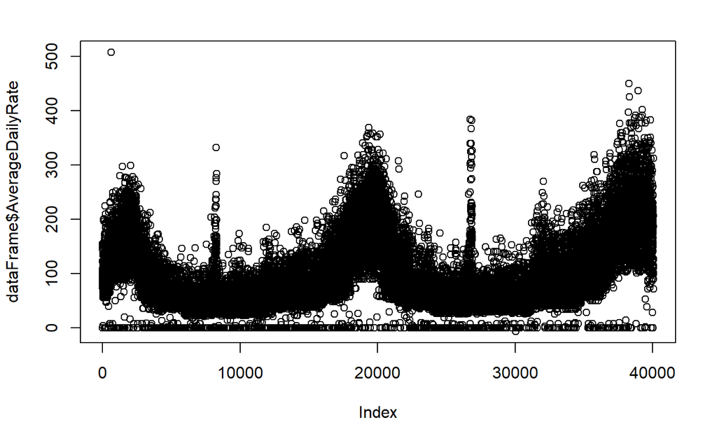

```r
plot(dataFrame$AverageDailyRate)
```

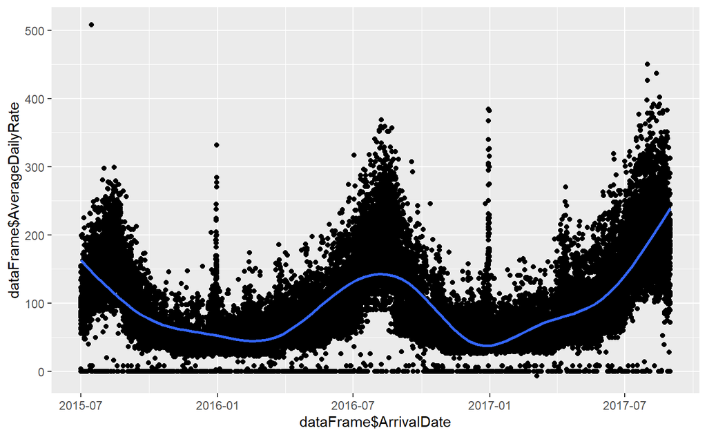

```r
ggplot(dataFrame, aes(x = dataFrame$ArrivalDate, y = dataFrame$AverageDailyRate))+geom_point()+geom_smooth()
```

```r
NA
NA
NA
```

Identifizierte Auffälligkeiten: Im Sommer werden höhere Preise gezahlt. Viele Buchungen mit dem Preis 0. Spezielle Tage: -Silvester

## Aufgabe (2 Punkte): Erstelle einen bereinigten Datensatz

Bereinige das Data Frame, indem du Beobachtungen mit Auffälligkeiten und unplausiblen Werten in den Attributen “AverageDailyRate” und “HouseholdType” entfernst.

**FÜR ALLE WEITEREN ANALYSEN IST AUSSCHLIESSLICH DER BEREINIGTE DATENSATZ ZU VERWENDEN!!!**

```r
#Remove all negative Prices and "Free" Room Prices
filter(dataFrame, AverageDailyRate <= 0)
```

| BookingCancelled | LeadTime | ArrivalDateYear | ArrivalDateMonth | ArrivalDateWeekNumber | ArrivalDateDayOfMonth | StaysInWeekendNights | StaysInWeekNights | Adults | Children | Babies | Meal | Country | MarketSegment | DistributionChannel | IsRepeatedGuest | PreviousCancellations | PreviousBookingsNotCanceled | ReservedRoomType | AssignedRoomType | BookingChanges | DepositType | Agent | Company | DaysInWaitingList | CustomerType | AverageDailyRate | RequiredCarParkingSpaces | TotalSpecialRequests | ReservationStatus | … |
| --- | --- | --- | --- | --- | --- | --- | --- | --- | --- | --- | --- | --- | --- | --- | --- | --- | --- | --- | --- | --- | --- | --- | --- | --- | --- | --- | --- | --- | --- | --- |
| No | 342 | 2015 | July | 27 | 1 | 0 | 0 | 2 | 0 | 0 | Bed & Breakfast | PRT | Direct | Direct | No | 0 | 0 | C | C | 3 | No Deposit | NA | NA | 0 | Transient | 0.00 | 0 | 0 | Check-Out | … |
| No | 737 | 2015 | July | 27 | 1 | 0 | 0 | 2 | 0 | 0 | Bed & Breakfast | PRT | Direct | Direct | No | 0 | 0 | C | C | 4 | No Deposit | NA | NA | 0 | Transient | 0.00 | 0 | 0 | Check-Out | … |
| No | 32 | 2015 | July | 27 | 4 | 0 | 1 | 4 | 0 | 0 | Full board | PRT | Complementary | Direct | No | 0 | 0 | H | H | 2 | No Deposit | NA | NA | 0 | Transient | 0.00 | 0 | 1 | Check-Out | … |
| No | 111 | 2015 | July | 28 | 6 | 0 | 0 | 2 | 0 | 0 | Bed & Breakfast | PRT | Online Tour Agent | Tour Agent/Tour Operator | No | 0 | 0 | A | H | 0 | No Deposit | 240 | NA | 0 | Transient | 0.00 | 0 | 2 | Check-Out | … |
| No | 0 | 2015 | July | 28 | 6 | 0 | 0 | 1 | 0 | 0 | Bed & Breakfast | PRT | Direct | Direct | No | 0 | 0 | E | H | 0 | No Deposit | 250 | NA | 0 | Transient | 0.00 | 0 | 0 | Check-Out | … |
| No | 8 | 2015 | July | 28 | 7 | 0 | 0 | 2 | 0 | 0 | Bed & Breakfast | PRT | Direct | Direct | No | 0 | 0 | A | A | 0 | No Deposit | NA | NA | 0 | Transient | 0.00 | 0 | 1 | Check-Out | … |
| No | 8 | 2015 | July | 28 | 7 | 0 | 0 | 2 | 0 | 0 | Bed & Breakfast | PRT | Online Tour Agent | Tour Agent/Tour Operator | No | 0 | 0 | A | E | 0 | No Deposit | 240 | NA | 0 | Transient | 0.00 | 0 | 1 | Check-Out | … |
| No | 15 | 2015 | July | 28 | 10 | 0 | 0 | 3 | 2 | 0 | Bed & Breakfast | PRT | Direct | Direct | No | 0 | 0 | C | E | 3 | No Deposit | NA | NA | 0 | Transient | 0.00 | 0 | 0 | Check-Out | … |
| Yes | 57 | 2015 | July | 29 | 15 | 0 | 2 | 2 | 0 | 0 | Full board | PRT | Groups | Direct | No | 0 | 0 | A | A | 0 | No Deposit | 305 | NA | 0 | Transient-Party | 0.00 | 0 | 0 | Canceled | … |
| No | 57 | 2015 | July | 29 | 15 | 0 | 2 | 1 | 0 | 0 | Full board | PRT | Groups | Direct | No | 0 | 0 | A | A | 1 | No Deposit | 305 | NA | 0 | Transient-Party | 0.00 | 0 | 0 | Check-Out | … |

[output cut: 742 more lines]

```r
cleanDataFrame <- filter(dataFrame, AverageDailyRate > 0)

#Remove all NA's in Householdtypecolumn
filter(cleanDataFrame, is.na(HouseholdType))
```

| BookingCancelled | LeadTime | ArrivalDateYear | ArrivalDateMonth | ArrivalDateWeekNumber | ArrivalDateDayOfMonth | StaysInWeekendNights | StaysInWeekNights | Adults | Children | Babies | Meal | Country | MarketSegment | DistributionChannel | IsRepeatedGuest | PreviousCancellations | PreviousBookingsNotCanceled | ReservedRoomType | AssignedRoomType | BookingChanges | DepositType | Agent | Company | DaysInWaitingList | CustomerType | AverageDailyRate | RequiredCarParkingSpaces | TotalSpecialRequests | ReservationStatus | … |
| --- | --- | --- | --- | --- | --- | --- | --- | --- | --- | --- | --- | --- | --- | --- | --- | --- | --- | --- | --- | --- | --- | --- | --- | --- | --- | --- | --- | --- | --- | --- |
| No | 31 | 2016 | December | 53 | 27 | 2 | 8 | 0 | 0 | 0 | Bed & Breakfast | PRT | Direct | Direct | No | 0 | 0 | D | D | 3 | No Deposit | NA | NA | 0 | Transient | 28 | 1 | 0 | Check-Out | … |

```r
cleanDataFrame <- filter(cleanDataFrame, !is.na(HouseholdType))
```

# Visualisierung

**FÜR ALLE WEITEREN ANALYSEN IST AUSSCHLIESSLICH DER BEREINIGTE DATENSATZ ZU VERWENDEN!!!**

## Aufgabe (5 Punkte): Analysiere Zusammenhänge kategorialer Grössen

Erstelle eine graphische Analyse, welche die relativen Unterschiede des Auftretens von Spezialwünschen (s. “TotalSpecialRequests”) bei Hotelreservationen nach Haushaltstyp (s. “HouseholdType”) untersucht und zusätzlich betrachtet, ob die Buchung storniert wurde oder nicht (s. “BookingCancelled”).

Hinweis: Verwende für deine Implementierung die Funktion `facet_wrap(, labeller = ...)`.

[figure not shown]

```r
#Tabelle machen mit Median
householdtypeBySpecialRequest <- cleanDataFrame %>% group_by(HouseholdType, BookingCancelled) %>%
                                summarise(medianSpecialRequests = mean(TotalSpecialRequests),
                                          .groups = "drop")

householdtypeBySpecialRequest <- householdtypeBySpecialRequest %>%
  mutate(BookingCancelled = case_when(BookingCancelled == "Yes" ~ "Cancelled",
                              BookingCancelled == "No" ~ "Not Cancelled"))
householdtypeBySpecialRequest$BookingCancelled <- as.factor(householdtypeBySpecialRequest$BookingCancelled)

ggplot(householdtypeBySpecialRequest, aes(x=HouseholdType, y=medianSpecialRequests))+ geom_bar(stat = "identity") + facet_wrap(vars(BookingCancelled))
```

## Aufgabe (5 Punkte): Erstelle eine visuelle Häufigkeitstabelle

Erstelle eine Heatmap, welche das Vorkommen von Art des Aufenthalts und Haushaltstyp farblich und in Zahlen darstellt.

Hinweis: Verwende für deine Implementierung die Funktion `geom_tile()` und eine Farbskala, welche grosse Häufigkeiten dunkler einfärbt als kleine.

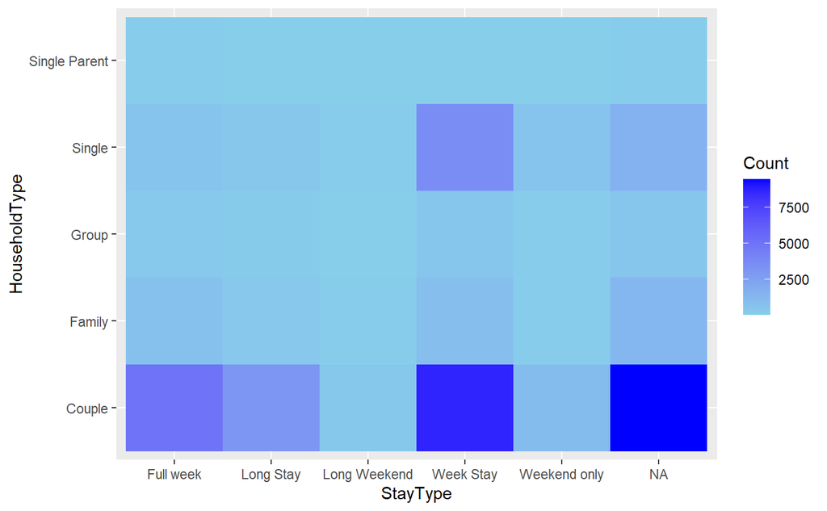

```r
staytypeByHouseholdtype <- cleanDataFrame %>% group_by(StayType, HouseholdType) %>%
                                summarise(Count = n(),
                                          .groups = "drop")

ggplot(staytypeByHouseholdtype, aes(x=StayType, y=HouseholdType)) + geom_tile(stat="identity", aes(fill=Count)) + scale_fill_gradient(high="blue", low = "sky blue")
```

```r
NA
NA
```

## Aufgabe (5 Punkte): Erstelle einen Mosaic-Plots

Erstelle analog zur Heatmap oben einen Mosaicplot, welcher das Vorkommen von Art des Aufenthalts und Haushaltstyp darstellt (Farben können frei gewählt werden, Zahlen sind nicht im Plot zu integrieren).

Hinweis: Verwende für deine Implementierung die Funktion `geom_mosaic()` aus dem Paket `ggmosaic`.

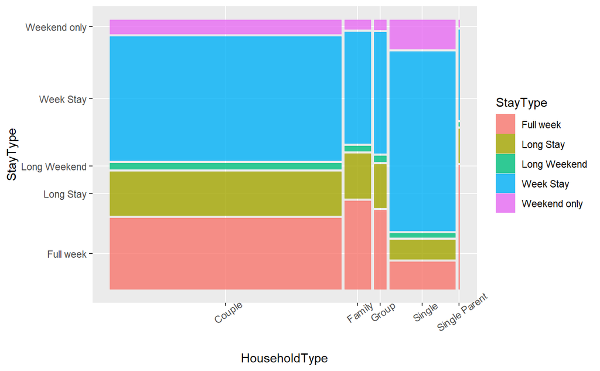

```r
library(ggmosaic)

ggplot(data = staytypeByHouseholdtype) + geom_mosaic(data= staytypeByHouseholdtype, na.rm = TRUE, divider = mosaic(), aes(weight=Count, x=product(HouseholdType), fill=StayType)) +  theme(axis.text.x=element_text(angle=35))
```

Wir haben hier die NA’s zur besseren Übersicht weggelassen. Könnte mit na.rm = FALSE korrigiert werden. Achsendrehung Quelle: https://rdrr.io/cran/ggmosaic/man/geom_mosaic.html

## Aufgabe (10 Punkte): Analysiere die Definition des Tagesdurchschnittpreises

Plausibilisiere visuell, dass die Angaben des Attributs Tagesdurchschnittpreis (“AverageDailyRate”) sich nicht auf den Preis pro Übernachtung und Person, sondern auf den Preis pro Übernachtung pro Zimmer beziehen.

Hinweis: Die Visualisierung ist kein abschliessender Beweis. Beschreibe klar und nachvollziehbar, wieso die von dir gezeigte Grafik ein Indiz dafür ist, dass sich die gelisteten Tagesdurchschnittpreise auf Übernachtungen pro Zimmer beziehen.

Idee: Wenn die Aussage korrekt ist, muss der Schnitt der Buchungen von einer Einzelperson der Durchschnitt und die Standardabweichung des Preises ca. doppelt so gross sein, wie von zwei Personen usw.

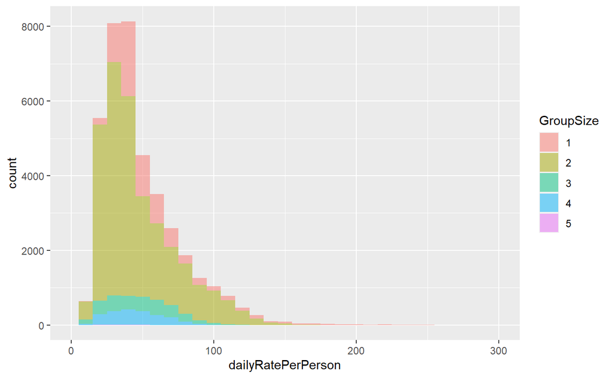

```r
cleanDataFrameNew <- cbind(cleanDataFrame, dailyRatePerPerson)
cleanDataFrameNew <- filter(cleanDataFrameNew, GroupSize < 6)
cleanDataFrameNew$GroupSize <- as.factor(cleanDataFrameNew$GroupSize)
ggplot(cleanDataFrameNew, aes(x=dailyRatePerPerson, fill=GroupSize))+geom_histogram(binwidth = 10, alpha = 0.5) +scale_x_continuous(limits = c(0, 300))
```

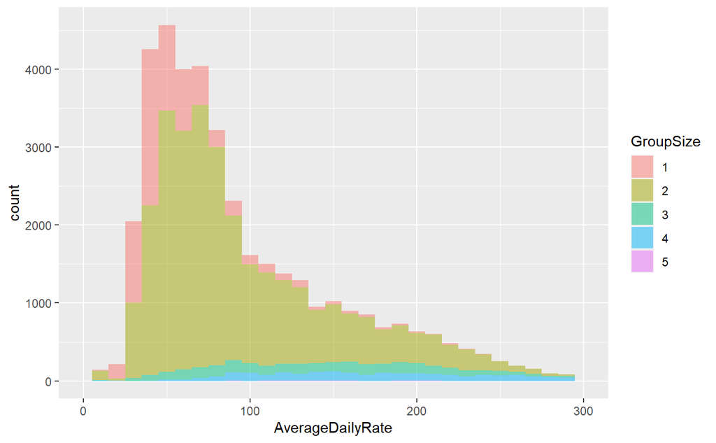

```r
ggplot(cleanDataFrameNew, aes(x=AverageDailyRate, fill=GroupSize))+geom_histogram(binwidth = 10, alpha = 0.5)+scale_x_continuous(limits = c(0, 300))
```

Auswertung: Die Verteilungskurven überlagen sich im Wesentlichen. Daraus folgt, dass der Übernachtungspreis tendentiell mit der Belegung pro Zimmer korreliert.

## Aufgabe (10 Punkte): Plausibilisiere Interpretation des Tagesdurchschnittpreises

Identifiziere drei Fälle, welche illustrieren, dass die Angaben des Attributs Tagesdurchschnittpreis (“AverageDailyRate”) sich auf den Preis pro Übernachtung pro Zimmer beziehen, indem du gezielt paarweise Buchungen vergleichst, wo sich Anzahl Personen und Tagesdurchschnittpreis unterscheiden, andere relevante Variablen aber übereinstimmen.

Gib für diese drei Fälle folgende Attribute aus: “GroupSize.x”, “GroupSize.y”, “AverageDailyRate.x”, “AverageDailyRate.y” (die Endung “.x” bezieht sich auf das Attribut der ersten, “.y” der zweiten Beobachtung der paarweisen Buchung).

Hinweis: Exploriere Beispiele von Hand und mache dann ein Refactoring deines Codes, d.h. verwende für deine Implementierung eine eigene Funktion mit `{{}}`, so dass eine wählbare Menge zufälliger Beispiele selektiert werden kann.

```r
searchSamples <- function(sampleCount){
  df <- data.frame()
  sampleCount2 <- sampleCount
  while( sampleCount2 > 0){
    sample1 <- cleanDataFrame[sample(nrow(cleanDataFrame), 1),]
    sample2 <- cleanDataFrame[sample(nrow(cleanDataFrame), 1),]
    count <- 0
    while(sample1$AverageDailyRate == sample2$AverageDailyRate | sample1$GroupSize == sample2$GroupSize | sample1$ArrivalDate != sample2$ArrivalDate | sample1$Meal != sample2$Meal | sample1$RequiredCarParkingSpaces != sample2$RequiredCarParkingSpaces | sample1$ArrivalDateYear != sample2$ArrivalDateYear | sample1$ReservedRoomType != sample2$ReservedRoomType){
      sample1 <- cleanDataFrame[sample(nrow(cleanDataFrame), 1),]
      sample2 <- cleanDataFrame[sample(nrow(cleanDataFrame), 1),]
      count <- count + 1
    }

    print(count)
    sample1$GroupSize
    sample2$GroupSize
    sample1$AverageDailyRate
    sample2$AverageDailyRate
    sample1 <- rbind(sample1,sample2)
    df <- rbind(df, sample1)
    sampleCount2 <- sampleCount2 -1
  }

  return(df)
}
```

```r
#Exploration von Hand

#1.Bsp Gleicher Monat, Gleiches Essen, Gleicher Parkplatz
set.seed(Sys.time())
sample1 <- cleanDataFrame[sample(nrow(cleanDataFrame), 1),]
sample2 <- cleanDataFrame[sample(nrow(cleanDataFrame), 1),]
count <- 0
while(sample1$AverageDailyRate == sample2$AverageDailyRate | sample1$GroupSize == sample2$GroupSize | sample1$ArrivalDate != sample2$ArrivalDate | sample1$Meal != sample2$Meal | sample1$RequiredCarParkingSpaces != sample2$RequiredCarParkingSpaces | sample1$ArrivalDateYear != sample2$ArrivalDateYear | sample1$ReservedRoomType != sample2$ReservedRoomType){
sample1 <- cleanDataFrame[sample(nrow(cleanDataFrame), 1),]
sample2 <- cleanDataFrame[sample(nrow(cleanDataFrame), 1),]
count <- count + 1
}

count
```

```
[1] 55
```

```r
sample1 <- rbind(sample1,sample2)







#-------
#Mit Funktion
#Kann lange Laufzeiten hervorrufen :)
search10 <- searchSamples(10)
```

```
[1] 6628
[1] 2269
[1] 794
[1] 20705
[1] 2691
[1] 1961
[1] 20555
```

```r
search10
```

|  | BookingCancelled | LeadTime | ArrivalDateYear | ArrivalDateMonth | ArrivalDateWeekNumber | ArrivalDateDayOfMonth | StaysInWeekendNights | StaysInWeekNights | Adults | Children | Babies | Meal | Country | MarketSegment | DistributionChannel | IsRepeatedGuest | PreviousCancellations | PreviousBookingsNotCanceled | ReservedRoomType | AssignedRoomType | BookingChanges | DepositType | Agent | Company | DaysInWaitingList | CustomerType | AverageDailyRate | RequiredCarParkingSpaces | TotalSpecialRequests | … |
| --- | --- | --- | --- | --- | --- | --- | --- | --- | --- | --- | --- | --- | --- | --- | --- | --- | --- | --- | --- | --- | --- | --- | --- | --- | --- | --- | --- | --- | --- | --- |
| 31249 | No | 14 | 2017 | April | 15 | 11 | 0 | 1 | 2 | 0 | 0 | Bed & Breakfast | FRA | Online Tour Agent | Tour Agent/Tour Operator | No | 0 | 0 | D | D | 0 | No Deposit | 240 | NA | 0 | Transient-Party | 100.00 | 0 | 1 | … |
| 31245 | No | 7 | 2017 | April | 15 | 11 | 0 | 1 | 1 | 0 | 0 | Bed & Breakfast | PRT | Online Tour Agent | Tour Agent/Tour Operator | No | 0 | 0 | D | E | 1 | No Deposit | 240 | NA | 0 | Transient-Party | 105.00 | 0 | 1 | … |
| 6678 | No | 0 | 2015 | November | 48 | 24 | 0 | 1 | 2 | 0 | 0 | Bed & Breakfast | NULL | Corporate | Corporate | No | 0 | 1 | A | D | 0 | No Deposit | NA | 286 | 0 | Transient | 40.00 | 0 | 0 | … |
| 6704 | No | 0 | 2015 | November | 48 | 24 | 0 | 3 | 1 | 0 | 0 | Bed & Breakfast | PRT | Corporate | Corporate | No | 0 | 0 | A | D | 1 | No Deposit | NA | 137 | 0 | Transient | 35.00 | 0 | 0 | … |
| 5177 | No | 287 | 2015 | October | 42 | 15 | 2 | 4 | 2 | 0 | 0 | Bed & Breakfast | PRT | Groups | Corporate | No | 0 | 0 | A | D | 1 | No Deposit | NA | 223 | 0 | Transient | 44.50 | 0 | 0 | … |
| 5110 | No | 287 | 2015 | October | 42 | 15 | 0 | 3 | 1 | 0 | 0 | Bed & Breakfast | GBR | Groups | Corporate | No | 0 | 0 | A | A | 1 | No Deposit | NA | 223 | 0 | Transient-Party | 37.00 | 0 | 0 | … |
| 28876 | No | 0 | 2017 | February | 8 | 24 | 2 | 2 | 2 | 1 | 0 | Bed & Breakfast | ESP | Offline Tour Agent/Tour Operator | Tour Agent/Tour Operator | No | 0 | 0 | A | A | 0 | No Deposit | 177 | NA | 0 | Transient-Party | 40.50 | 0 | 0 | … |
| 28869 | No | 27 | 2017 | February | 8 | 24 | 0 | 2 | 2 | 0 | 0 | Bed & Breakfast | PRT | Online Tour Agent | Tour Agent/Tour Operator | No | 0 | 0 | A | A | 0 | No Deposit | 240 | NA | 0 | Transient | 48.00 | 0 | 1 | … |
| 10181 | Yes | 81 | 2016 | February | 9 | 26 | 1 | 2 | 1 | 0 | 0 | Bed & Breakfast | PRT | Online Tour Agent | Tour Agent/Tour Operator | No | 0 | 0 | A | A | 0 | No Deposit | 240 | NA | 0 | Transient | 39.00 | 0 | 0 | … |
| 10204 | No | 15 | 2016 | February | 9 | 26 | 0 | 1 | 2 | 0 | 0 | Bed & Breakfast | PRT | Corporate | Corporate | Yes | 1 | 3 | A | E | 2 | No Deposit | NA | 28 | 0 | Transient | 45.00 | 0 | 1 | … |

[output cut: 10 more lines]

```r
NA
NA
```

## Aufgabe (5 Punkte): Erstelle Facet-Plot des Tagesdurchschnittpreises

Reproduziere die folgende Grafik (“Figure 1: AverageDailyRate_2016_RoomA”) für die Verteilung der monatlichen Tagesdurchschnittpreise (“AverageDailyRate”) von Zimmern mit AssignedRoomType “A” für das Jahr 2016 mit allen gezeigten Details.

[figure not shown]

AverageDailyRate_2016_RoomA

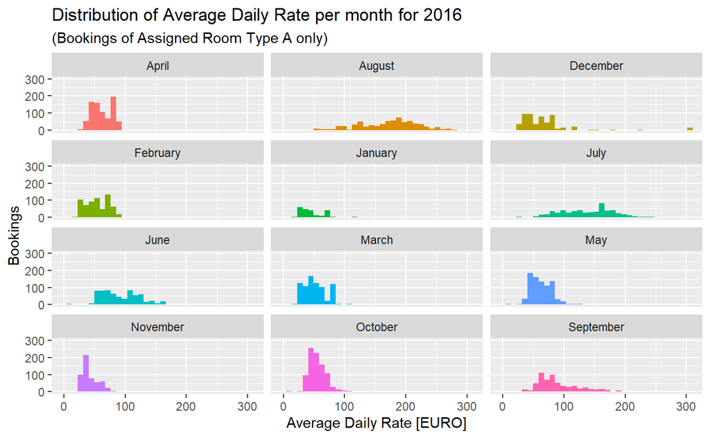

```r
roomsTypeAIn2016 <- filter(cleanDataFrame, ArrivalDateYear == 2016 & AssignedRoomType == "A")



ggplot(roomsTypeAIn2016, aes(x=AverageDailyRate, fill=ArrivalDateMonth))+geom_histogram(binwidth = 9) +  xlab("Average Daily Rate [EURO]") + ylab("Bookings") + facet_wrap(vars(ArrivalDateMonth), ncol=3) + theme(legend.position="none") + expand_limits(x = c(0,300), y=c(0,300)) + ggtitle("Distribution of Average Daily Rate per month for 2016", subtitle = "(Bookings of Assigned Room Type A only)")
```

```r
NA
NA
```

## Aufgabe (5 Punkte): Verbessere Facet-Plot des Tagesdurchschnittpreises

Verbessere die vorangehende Grafik so, dass die Reihenfolge der Monate chronologisch geordnet ist.

```r
roomsTypeAIn2016Ordered <- roomsTypeAIn2016

roomsTypeAIn2016Ordered$ArrivalDateMonth <- factor(roomsTypeAIn2016Ordered$ArrivalDateMonth, levels = c("January", "February", "March", "April", "May", "June", "July", "August", "September", "October", "November", "December"))
```

## Aufgabe (5 Punkte): Reproduziere Facet-Plot des Tagesdurchschnittpreises

Reproduziere die folgende Grafik (“Figure 2: AverageDailyRate_RoomsACDEFG.png”) mit allen gezeigten Details für die Verteilung der Tagesdurchschnittpreise (“AverageDailyRate”) von Zimmern mit AssignedRoomType “A”, “C”, “D”, “E”, “F” und “G” ohne Beschränkung des Zeitraumes.

[figure not shown]

AverageDailyRate_RoomsACDEFG.png

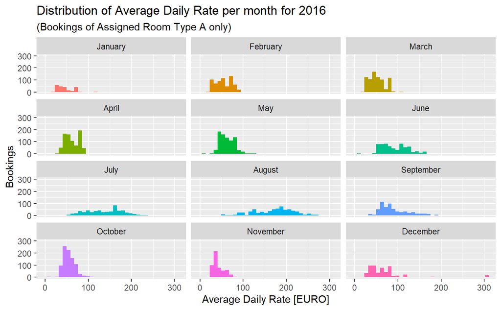

```r
ggplot(roomsTypeAIn2016Ordered, aes(x=AverageDailyRate, fill=ArrivalDateMonth)) + geom_histogram(binwidth = 9) + xlab("Average Daily Rate [EURO]") + ylab("Bookings") + facet_wrap(vars(ArrivalDateMonth), ncol=3) + theme(legend.position="none") + expand_limits(x = c(0,300), y=c(0,300)) + ggtitle("Distribution of Average Daily Rate per month for 2016", subtitle = "(Bookings of Assigned Room Type A only)")

roomsPerMonth <- filter(cleanDataFrame, grepl(paste(c("A", "C", "D", "E", "F", "G"), collapse="|"), AssignedRoomType))
```

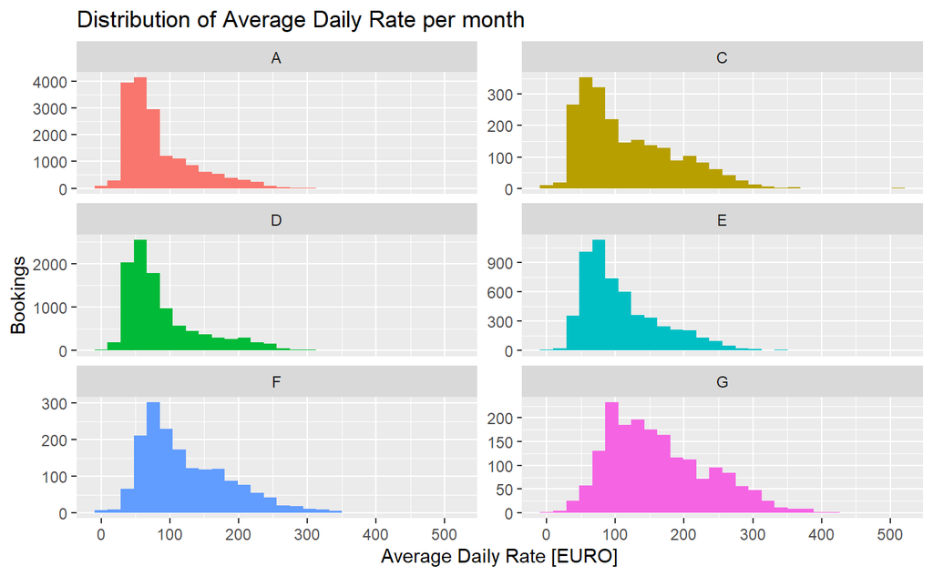

```r
ggplot(roomsPerMonth, aes(x=AverageDailyRate, fill=AssignedRoomType)) + geom_histogram(binwidth = 18.95) + xlab("Average Daily Rate [EURO]") + ylab("Bookings") + facet_wrap(vars(AssignedRoomType), ncol=2, scales="free_y") + theme(legend.position="none") + ggtitle("Distribution of Average Daily Rate per month")
```

```r
NA
NA
NA
NA
```

## Aufgabe (5 Punkte): Vereinfache Facet-Plot des Tagesdurchschnittpreises

Erzeuge für die oben dargestellten Daten nun Boxplots zum Vergleich von Tagesdurchschnittpreisen (“AverageDailyRate”) nach Zimmertyp (“AssignedRoomType”) und visualisiere die Gruppengrösse mit Hilfe der Fläche der Box.

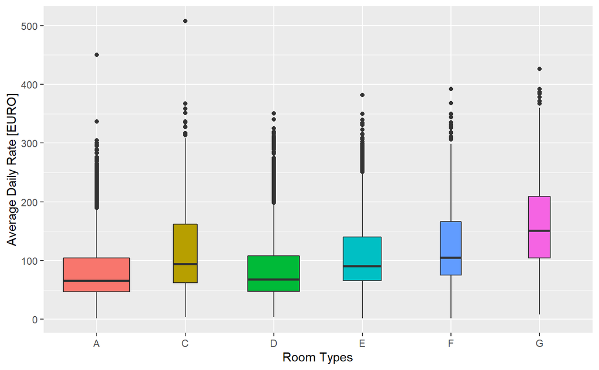

```r
ggplot(roomsPerMonth, aes(x=AssignedRoomType, y=AverageDailyRate, fill=AssignedRoomType)) + geom_boxplot(varwidth = TRUE) + ylab("Average Daily Rate [EURO]") + xlab("Room Types") +  theme(legend.position="none")
```

## Aufgabe (5 Punkte): Untersuche und visualisiere Korrelationen

Berechne die Korrelation nach Bravais-Pearson für die Attribute Preis (Attribut “Price”) und Anzahl Übernachtungen (Attribut “TotalNights”). Erstelle weiter ein Streudiagramm für “Price” vs “TotalNights” und integriere im Untertitel die Information der Anzahl Beobachtungen und der berechneten Korrelation auf drei Nachkommastellen gerundet.

Hinweis: Verwende für deine Implementierung die Funktion `geom_jitter()` mit sinnvoller Wahl der Parameter `alpha` und `shape`.

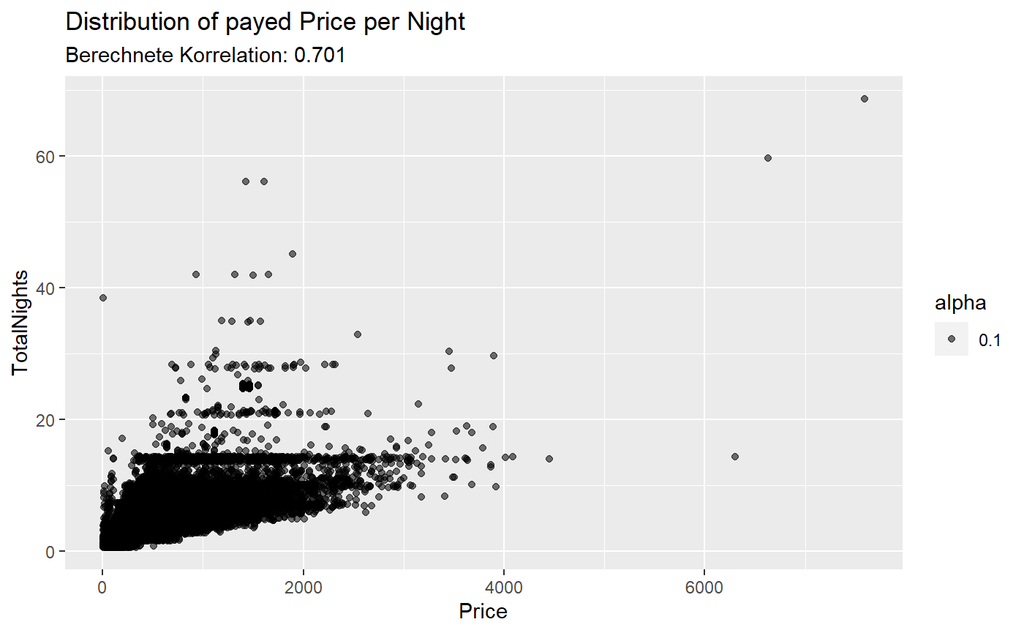

```r
ggplot(cleanDataFrame, aes(x=Price, y = TotalNights))+geom_jitter(aes(alpha=0.1))+ ggtitle("Distribution of payed Price per Night", subtitle = str_c("Berechnete Korrelation: ", as.character(round(x=cor(cleanDataFrame$Price, cleanDataFrame$TotalNights), digits = 3))))
```

## Aufgabe (10 Punkte): Bereinigung von Ausreissern

Erstelle das obige Streudiagramm für “Price” vs “TotalNights” erneut und schränke die x-Achse und y-Achse so ein, dass Aussreisser am oberen Ende der Skala nicht gezeigt werden. Passe den Untertitel an, indem du erwähnst wieviele Ausreisser nicht gezeigt werden.

Hinweis: Verwende für deine Implementierung die Definition des Boxplots: Ausreißer sind Datenpunkte, die sich ausserhalb der Zäune (“Whiskers”) des Boxplots befinden. Die Whiskers haben die Länge des 1,5-fachen des Interquartilsbereichs und setzen oberhalb des oberen Quartils und unterhalb des unteren Quartils an.

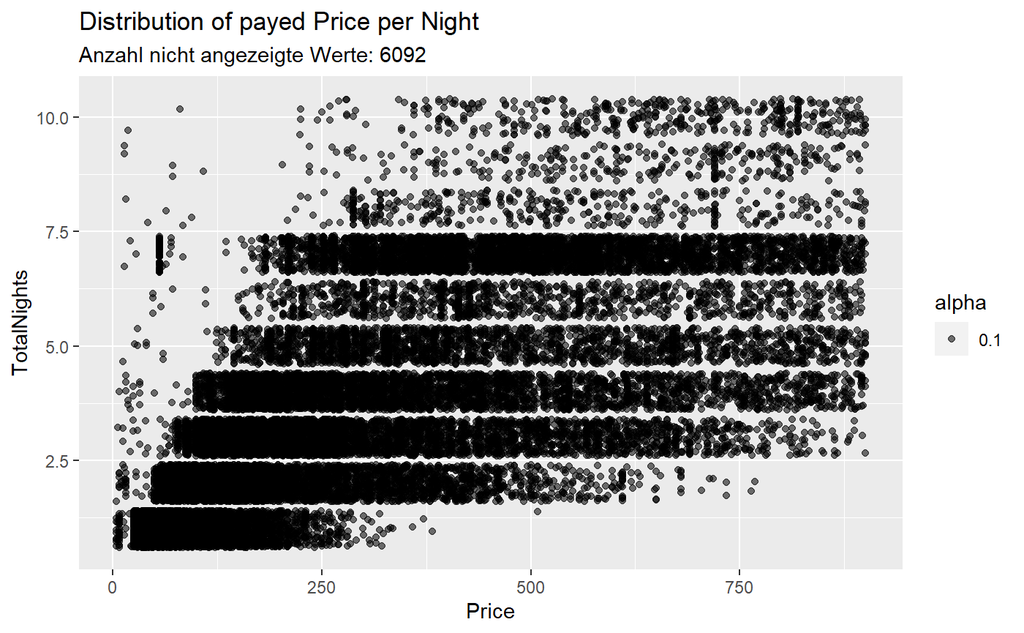

```r
withoutOutliers <- filter(cleanDataFrame, TotalNights < (quantile(cleanDataFrame$TotalNights, probs = 0.75)*1.5) & Price < (quantile(cleanDataFrame$Price, probs = 0.75)*1.5))


ggplot(withoutOutliers, aes(x=Price, y = TotalNights))+geom_jitter(aes(alpha=0.1))+ ggtitle("Distribution of payed Price per Night", subtitle = str_c("Anzahl nicht angezeigte Werte: ", as.character(nrow(cleanDataFrame) - nrow(withoutOutliers))))
```

## Aufgabe (10 Punkte): Untersuche den Zeitverlauf der Hotelankünfte

Visualisiere die Anzahl der Hotelbuchungen nach Ankunftsdatum im Zeitverlauf, wobei die stornierten Buchungen nicht zu berücksichtigen sind. Visualisiere den Verlauf über 180 Tage, beginnend am 1. Juni 2016.

Hinweis: Verwende für deine Implementierung `tidyverse` und `lubridate`.

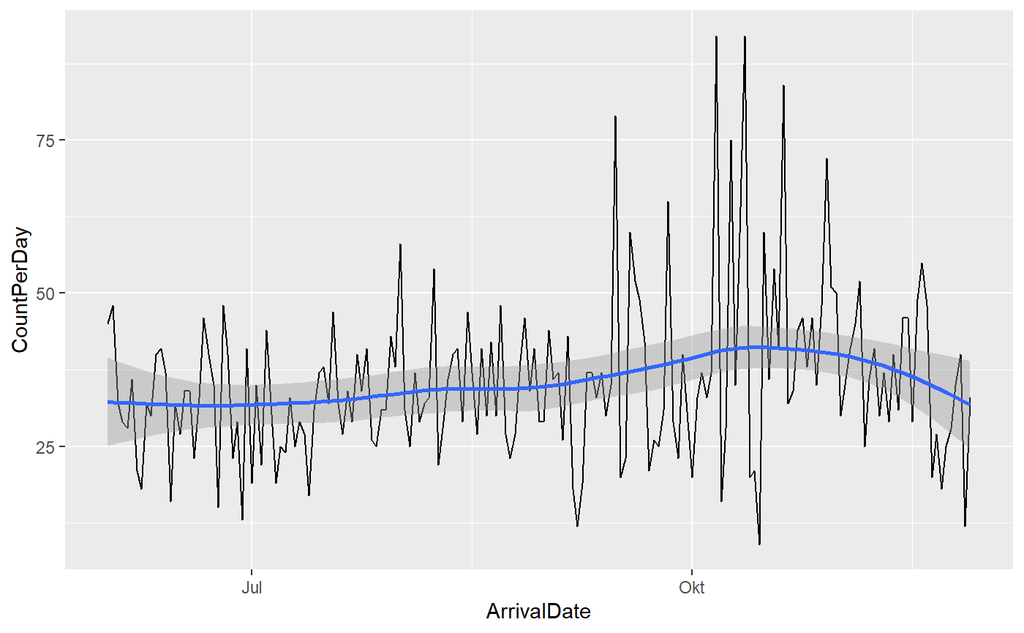

```r
timescaleDF <- filter(cleanDataFrame, BookingCancelled == "No" & ArrivalDate >= ymd("20160601") & ArrivalDate <= (ymd("20160601")+180))



newDF <- timescaleDF %>% group_by(ArrivalDate) %>%
          summarise(CountPerDay = n(),
            .groups = "drop")


ggplot(newDF, aes(x=ArrivalDate, y=CountPerDay))+geom_line()+geom_smooth()
```

## Aufgabe (5 Punkte): Identifiziere Tage mit meisten Buchungen

Identifiziere die fünf Tage mit den meisten Zimmer-Buchungen gemessen am Datum der Ankunft, wobei die stornierten Buchungen nicht zu berücksichtigen sind. Gib zusätzlich die Anzahl Personen an, welche an diesen Tagen eingecheckt haben.

```r
filteredDF <- filter(cleanDataFrame, BookingCancelled == "No")
newDF <- filteredDF %>% group_by(ArrivalDate) %>%
          summarise(CountPerDay = n(),
            .groups = "drop")

maxAnkunftDate <- newDF[order(newDF$CountPerDay, decreasing = TRUE),]
maxAnkunftDate <- maxAnkunftDate[1:5,]

dayWithMaxArrivals <- filter(filteredDF, filteredDF$ArrivalDate %in% maxAnkunftDate$ArrivalDate)

groupSizePerDay <- dayWithMaxArrivals %>% group_by(ArrivalDate) %>%
          summarise(anzahlPersonen = sum(GroupSize),
            .groups = "drop")


print(groupSizePerDay)
```

| ArrivalDate | anzahlPersonen |
| --- | --- |
| 2015-12-05 | 240 |
| 2015-12-30 | 198 |
| 2017-01-16 | 124 |
| 2017-03-02 | 179 |
| 2017-05-25 | 201 |

## Aufgabe (10 Punkte): Untersuche den Zeitverlauf des mittleren Tagesdurchschnittspreise der Buchungen

Berechne für 2016 die zeitliche Entwicklung des Tagesdurchschnittspreises (“AverageDailyRate”) aller Buchungen pro Woche. Visualisiere den Median sowie das 25%-Perzentil und 75%-Perzentil, um die Streuung des Tagesdurchschnittspreises zu illustrieren.

Bestimme und markiere dann visuell die Kalenderwoche mit dem höchsten Tagesdurchschnittspreis mit Hilfe einer vertikalen roten Linie.

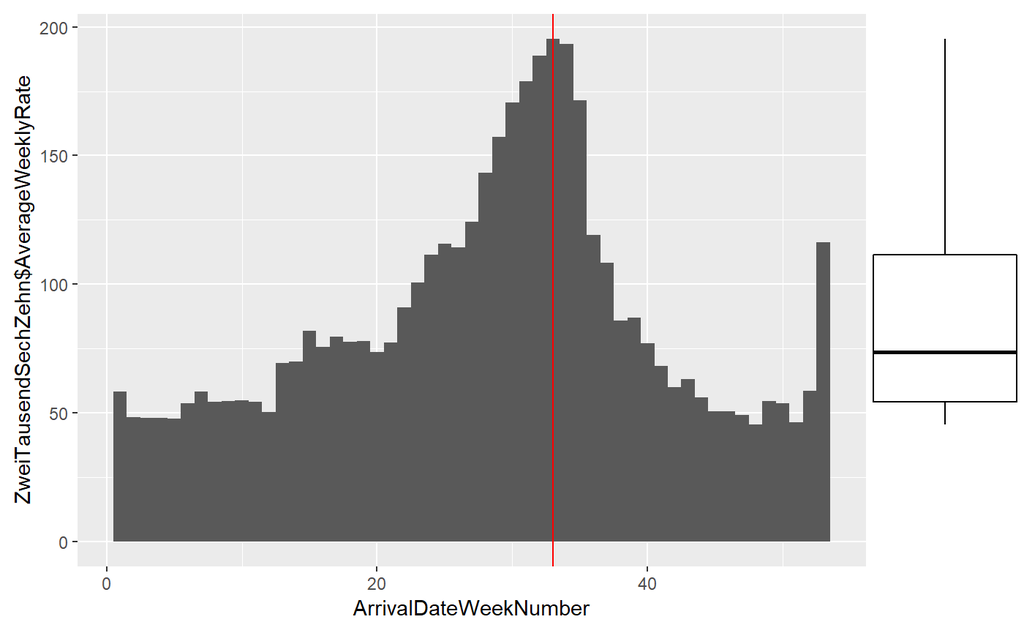

```r
library(ggExtra)

ZweiTausendSechZehn <- dataFrame %>%
  mutate(ArrivalDate = as.Date(ArrivalDate, format = "%d/%m/%y")) %>%
  filter(ArrivalDate >= "2016-01-01" & ArrivalDate <= "2016-12-31")
ZweiTausendSechZehn <- dataFrame %>% group_by(ArrivalDateWeekNumber)
ZweiTausendSechZehn <- mutate(ZweiTausendSechZehn) %>% summarise(
  AverageWeeklyRate = mean(AverageDailyRate))
ZweiTausendSechZehn <- ZweiTausendSechZehn %>% mutate(across(where(is.numeric), round, 2))

#Histogram
histogram <- ggplot(ZweiTausendSechZehn, aes(x=ArrivalDateWeekNumber)) + geom_point(aes(y=ZweiTausendSechZehn$AverageWeeklyRate), alpha = 0) + geom_histogram(aes(y=stat(ZweiTausendSechZehn$AverageWeeklyRate)), binwidth = 1) +geom_vline(xintercept=33, color="red")

ggMarginal(histogram, type = "boxplot", margins = "y")
```

# Eigene Analysen

## Aufgabe (20 Punkte): Exploriere den Datensatz weiter

Untersuche weitere, noch nicht beleuchtete Zusammenhänge in den Daten und dokumentiere (a) deine Hypothese, (b) die gefundenen Zusammenhängen präzise in Worten.

## LeadTime in Korrelation zu BookingCancelled

Hypothese: Höhere Leadtime führt zu einer höheren Wahrscheinlichkeit dass die Buchung gecanceld wird.

```r
cor(as.integer(dataFrameOld$LeadTime), as.integer(dataFrameOld$BookingCancelled))
```

```
[1] 0.2294438
```

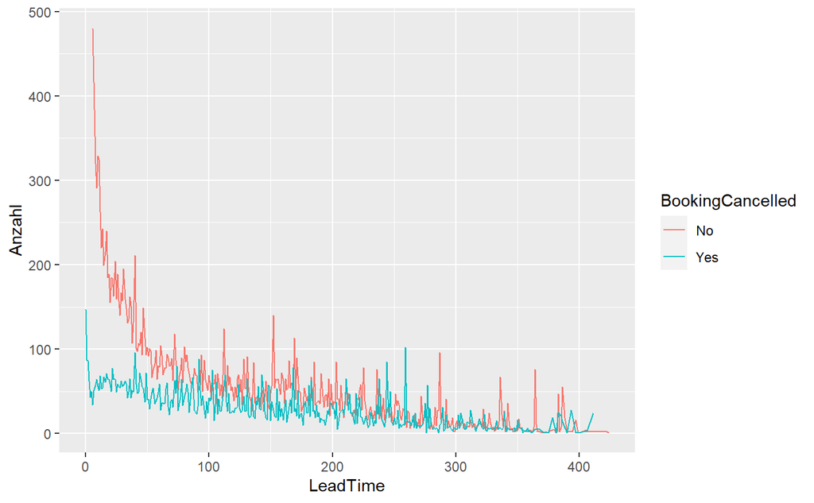

```r
leadtimeProCancelation <- cleanDataFrame %>% group_by(LeadTime, BookingCancelled) %>%
          summarise(Anzahl = n(),
            .groups = "drop")

leadtimeProCancelation <- filter(leadtimeProCancelation, leadtimeProCancelation$Anzahl<500 & leadtimeProCancelation$LeadTime<425)

ggplot(leadtimeProCancelation, aes(x=LeadTime, y=Anzahl, color = BookingCancelled))+geom_line()
```

Gefunden: Unsere Hypothese lässt sich nicht Bestätigen. Durch die Berechnung der Korrelation mit der Bravais-Pearson-Formel ergab es eine schwache Korrelation. Jedoch ist auf der Grafik zu erahnen das sich die beiden Kurven immer mehr annähern. Das bedeutet, das die prozentuale Chance steigt, das eine Buchung storniert wird, je grösser LeadTime ist.

## Trends Forecasting

Hypothese: Die Preise steigen wegen der Inflation über die Jahre um ca. 2%.

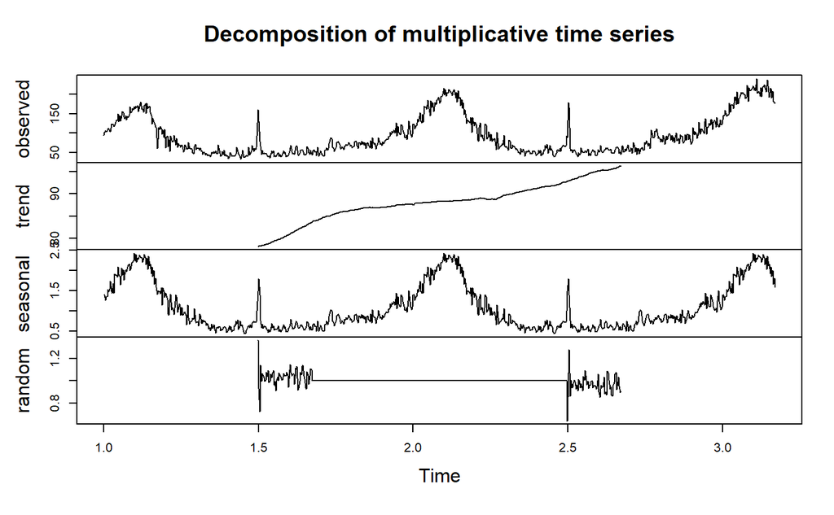

```r
dailyMeanPriceAll <- cleanDataFrame %>% group_by(ArrivalDate) %>%
          summarise(AverageDailyMean = mean(AverageDailyRate),
            .groups = "drop")


tsdata <- ts(dailyMeanPriceAll$AverageDailyMean, frequency = 365)


ddata <- decompose(tsdata, "multiplicative")
plot(ddata)
```

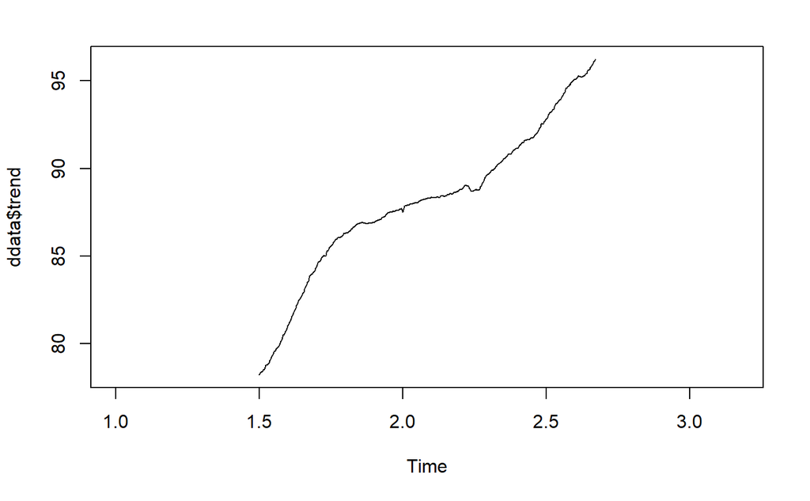

```r
plot(ddata$trend)
```